# SDTM Domain Classifier

Classifying CDISC SDTM Domains using KNN and CART

### Classifying CDISC SDTM Domains using KNN and CART (Decision Tree)

**Objective:** Given a variable label from a clinical trial dataset, predict which SDTM domain it belongs to.

**Domains covered:** DM · AE · CM · EX · LB · VS · MH · PE · EG · SC

**Models compared:** K-Nearest Neighbors (KNN) vs Classification and Regression Tree (CART)

## 1. Import Required Libraries

## 2. Load and Explore the Dataset

|  | variable_name | variable_label | domain |
| --- | --- | --- | --- |
| 0 | STUDYID | Study Identifier | DM |
| 1 | DOMAIN | Domain Abbreviation | DM |
| 2 | USUBJID | Unique Subject Identifier | DM |
| 3 | SUBJID | Subject Identifier for the Study | DM |
| 4 | RFSTDTC | Subject Reference Start Date Time | DM |
| 5 | RFENDTC | Subject Reference End Date Time | DM |
| 6 | RFXSTDTC | Date Time of First Study Treatment | DM |
| 7 | RFXENDTC | Date Time of Last Study Treatment | DM |
| 8 | RFICDTC | Date Time of Informed Consent | DM |
| 9 | RFPENDTC | Date Time of End of Participation | DM |

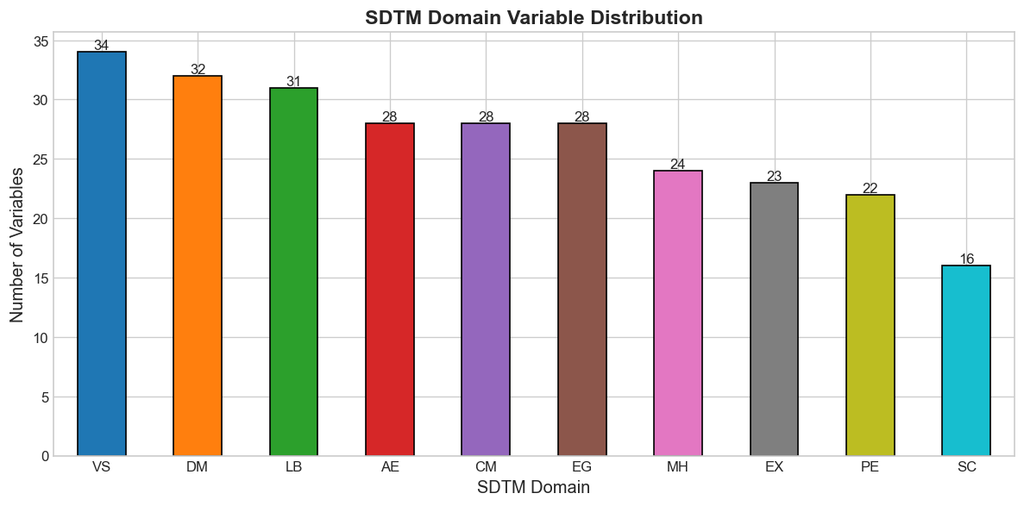

## 3. Data Preprocessing and Label Encoding

|  | Domain | Encoded Label |
| --- | --- | --- |
| 0 | AE | 0 |
| 1 | CM | 1 |
| 2 | DM | 2 |
| 3 | EG | 3 |
| 4 | EX | 4 |
| 5 | LB | 5 |
| 6 | MH | 6 |
| 7 | PE | 7 |
| 8 | SC | 8 |
| 9 | VS | 9 |

## 4. Feature Engineering — TF-IDF Vectorization

We combine the `variable_name` and `variable_label` text, then apply **TF-IDF vectorization** to create numeric features. TF-IDF captures term importance across documents (labels), making it an effective feature for text-based classification.

## 5. Train / Test Split

|  | Train | Test |
| --- | --- | --- |
| AE | 21 | 7 |
| CM | 21 | 7 |
| DM | 24 | 8 |
| EG | 21 | 7 |
| EX | 17 | 6 |
| LB | 23 | 8 |
| MH | 18 | 6 |
| PE | 17 | 5 |
| SC | 12 | 4 |
| VS | 25 | 9 |

## 6. Train KNN Model

We use 5-fold cross-validation over a range of **k** values to select the optimal number of neighbors.

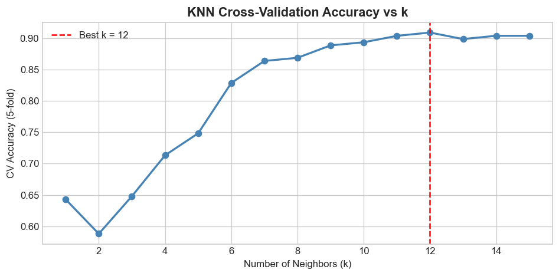

```
KNeighborsClassifier(metric='cosine', n_neighbors=12)
```

## 7. Train CART Model

CART uses the **Gini impurity** criterion. We tune `max_depth` and `min_samples_split` via grid search.

## 8. Evaluate KNN Model

```
              precision    recall  f1-score   support

          AE       1.00      0.86      0.92         7
          CM       0.83      0.71      0.77         7
          DM       0.62      0.62      0.62         8
          EG       0.62      0.71      0.67         7
          EX       0.86      1.00      0.92         6
          LB       1.00      0.75      0.86         8
          MH       0.86      1.00      0.92         6
          PE       0.83      1.00      0.91         5
          SC       0.80      1.00      0.89         4
          VS       1.00      0.89      0.94         9

    accuracy                           0.84        67
   macro avg       0.84      0.85      0.84        67
weighted avg       0.85      0.84      0.84        67
```

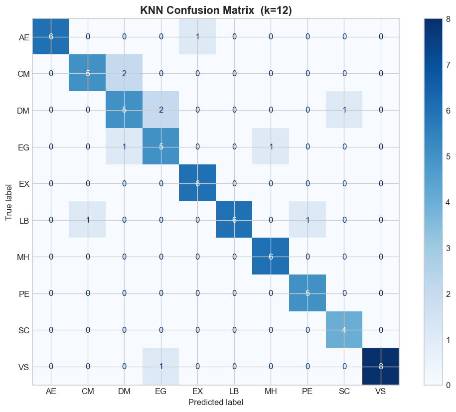

## 9. Evaluate CART Model

```
              precision    recall  f1-score   support

          AE       1.00      0.86      0.92         7
          CM       1.00      1.00      1.00         7
          DM       0.89      1.00      0.94         8
          EG       1.00      1.00      1.00         7
          EX       1.00      1.00      1.00         6
          LB       1.00      1.00      1.00         8
          MH       1.00      1.00      1.00         6
          PE       1.00      1.00      1.00         5
          SC       1.00      1.00      1.00         4
          VS       1.00      1.00      1.00         9

    accuracy                           0.99        67
   macro avg       0.99      0.99      0.99        67
weighted avg       0.99      0.99      0.98        67
```

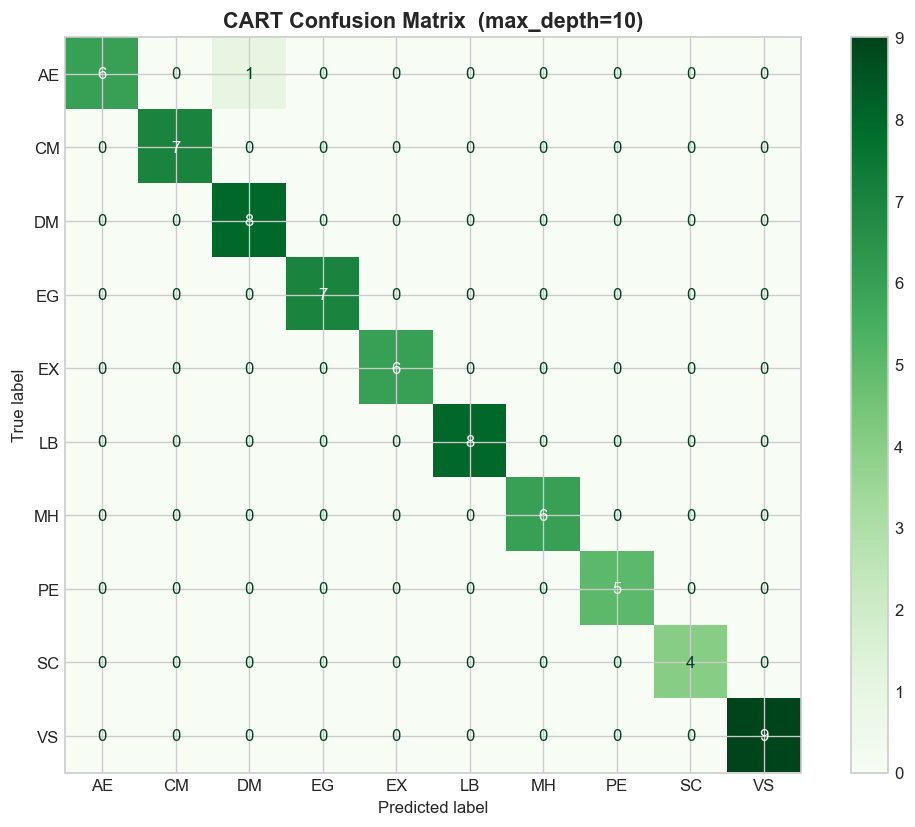

## 10. Model Comparison

| Model | Accuracy | Precision | Recall | F1-Score |
| --- | --- | --- | --- | --- |
| KNN (k=12) | 0.8358 | 0.8487 | 0.8358 | 0.8361 |
| CART (depth=10) | 0.9851 | 0.9867 | 0.9851 | 0.9849 |

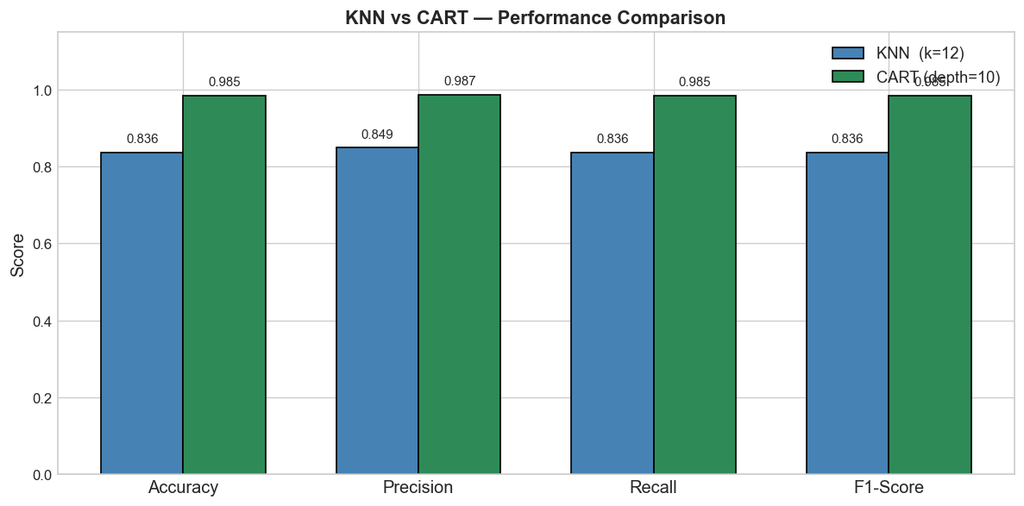

## 11. CART Decision Tree & Feature Importances

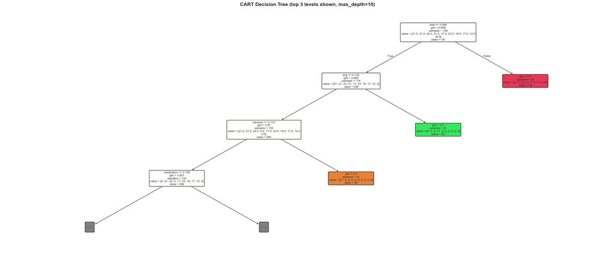

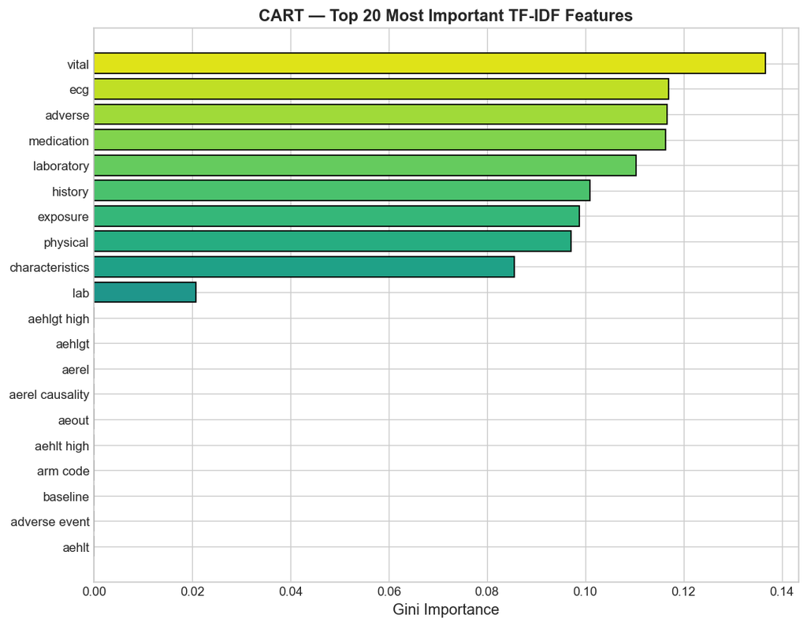

## Summary

**Key Findings**

CART significantly outperforms KNN on this dataset. Domain-specific clinical keywords are highly discriminative features.

**Model Comparison**

|  | KNN | CART |
| --- | --- | --- |
| **Algorithm** | Instance-based (lazy) | Rule-based tree (eager) |
| **Hyper-parameter tuned** | k (neighbors) | max_depth, min_samples_split |
| **Interpretable?** | No | Yes (tree structure) |
| **Feature insight** | No | Yes (Gini importances) |

**Key Observations**

- **CART** achieves higher accuracy than KNN, making it the clear winner on this dataset.
- **KNN** with cosine distance is a reasonable baseline for TF-IDF vectors but is sensitive to the choice of k.
- **CART** produces an explicit decision tree making it easy to audit which tokens drive domain predictions — important in a clinical/SDTM context.
- Domain-specific keywords (e.g., *vital*, *adverse*, *laboratory*, *medication*) are highly discriminative.